# QAQC “Lite”

ROSSyndicate

2024-07-31

This is a “lite” workflow to perform simple quality assurance/quality control (QA/QC) steps across water quality data pulled from HydroVu. Specifically, this workflow identifies the following:

1. Observations that fall outside In-Situ’s sensor specification ranges
2. Observations that fall outside seasonal thresholds for slope and mean developed on historical, clean data
3. Observations during times when the sonde was not submerged in water
4. Observations during times when the water was freezing
5. Observations with missing data
6. Observations that repeat through time

   Plus, several “experimental” flags that aim at finding:
7. DO observations with “noise” (i.e., dropping/hopping DO)
8. Turbidity drift from biofouling
9. Identifying observations “sandwiched” between flagged data (called “suspect” observations)

We have also developed several approaches to reduce over-flagging by:

- Removing slope flags for sensor data that occurs at the same time as a change in temperature or depth
- Removing (appropriate) flags that occurred at roughly the same time at an upstream or downstream location. **The associated function, `network_check()`, will require heavy modification to perform across a different network of sites than ROSSyndicate’s Poudre Sonde Network.**

To run this pipeline, you must have credentials for accessing HydroVu’s API, stored in a called `HydroVuCreds.yml`.

## *Step 1: Import and collate data*

Download all the API data. This step requires HydroVu credentials and an understanding of your sites’ site names. See `creds/HydroVuCredsTemplate.yml` for a template to use for formatting credentials properly.

```r
hv_creds <- read_yaml("creds/HydroVuCreds.yml")

hv_token <- hv_auth(client_id = as.character(hv_creds["client"]),
                    client_secret = as.character(hv_creds["secret"]),
                    url = "https://www.hydrovu.com/public-api/oauth/token")

incoming_data_csvs_upload <- api_puller(site = c("JOEI", "CBRI", "CHD", "PFAL",
                                                 "PBD", "SFM", "LBEA", "PENN",
                                                 "Tamasag", "Legacy", "Lincoln",
                                                 "Timberline", "SpringCreek", "Prospect",
                                                  "Boxelder", "BoxCreek", "Archery",
                                                 "River Bluffs"),
                                        start_dt = "2024-07-01 01:00:00 MDT",
                                        end_dt = Sys.time(),
                                        api_token = hv_token,
                                        dump_dir = "data/api/"
                                        )
```

Collate all the data at a user-specified interval:

```r
all_data <- munge_api_data(api_path = "data/api/",
                           # Select which sondes to download data from:
                           # ROSSyndicate manages two sets of sondes,
                           # Virridy and City of Fort Collins.
                           network = "all",
                           # What interval do you want data analyzed across?
                           summarize_interval = "15 minutes") # Other example: "1 hour"
```

## *Step 2: Get basic statistics about the data*

Here, we split up all of our site-parameter combinations into a list that we can more easily iterate over. Then, across those lists, we average any observations whose frequency is greater than our interval of interest so that our data set is consistently recorded at that intervals. We also preserve the total number of observations within the time interval used to calculate the mean, as well as the spread (max-min). After these calculations, we use {padr}’s `pad()` function to fill in data gaps at the selected interval.

```r
# Determine each site and parameter in our raw data `all_data`:
sites <- unique(all_data$site)

# Of those, which do we want to keep?
params <- c(
  "Chl-a Fluorescence",
  "Depth",
  "DO",
  "ORP",
  "pH",
  "Specific Conductivity",
  "Temperature",
  "Turbidity",
  "FDOM Fluorescence")

# Here we construct a data frame to iterate over each site-parameter combination.
site_param_combos <- tidyr::crossing(sites, params)

# Make a list of the 15-minute summarized data.
all_data_tidied_list <- purrr::map2(.x = site_param_combos$sites,
                                    .y = site_param_combos$params,
                                    ~tidy_data(site_arg = .x,
                                               parameter_arg = .y,
                                               api_data = all_data,
                                               # Same interval as upstream step:
                                               summarize_interval = "15 minutes")) %>%
  # Set the names for the dfs in the list:
  purrr::set_names(paste0(site_param_combos$sites, "-", site_param_combos$params)) %>%
  # Remove NULL from the list (indicating a site-param combo that doesn't actually exist):
  purrr::keep(~ !is.null(.))
```

#### *Add summary stats*

Here, we are adding in contextual summary statistics that can be used to describe a given observation’s relationship to its neighboring observations. This includes:

- the previous and next observation and their slopes
- the 7-point (each observation and the previous 6) moving median, mean, slope, and standard deviation
- the hydrologic “season” in which the observation lands in. Currently we are defining them as…
  - Winter base flow: Dec, Jan, Feb, Mar, Apr
  - Snow melt: May, Jun
  - Monsoon: Jul, Aug, Sep
  - Fall base flow: Oct, Nov

```r
all_data_summary_stats_list <- all_data_tidied_list %>%
  purrr::map(~ generate_summary_statistics(.))
```

## *Step 3: Create data thresholds*

Next, we create a look-up table for site-parameter thresholds to use in flagging strange data. These thresholds should ULTIMATELY be based on an approved subset of human-verified GOOD historical data. But if a historical cleaned data set does not yet exist, we can reduce the current data set to “good”-ish data by using some automated cleaning steps, and use that data as a placeholder for making a first pass for thresholds.

```r
# "Placeholder" for when there is no clean, historical data to develop thresholds with:
goodish_data_placeholder <- all_data_summary_stats_list %>%
  # Find instances outside of In-Situ's sensor spec ranges
  map(~add_spec_flag(df = ., spec_table = yaml::read_yaml("data/qaqc/sensor_spec_thresholds.yml"))) %>%
  dplyr::bind_rows() %>%
  # Intersensor flags require data by SITE, not SITE-PARAMETER
  split(f = .$site, sep = "-") %>%
  # Flag data when water was below freezing
  map(~add_frozen_flag(df = .)) %>%
  # Flag data when sonde was not submerged in water
  map(~add_unsubmerged_flag(df = .)) %>%
  dplyr::bind_rows() %>%
  # Filter to only un-flagged data (that we can semi-confidently assume is "bad" data):
  dplyr::filter(is.na(flag)) %>%
  # Reconfigure to site-parameter for future processing
  split(f = list(.$site, .$parameter), sep = "-") %>%
  # remove NULL from the list (indicating a site-param combo that doesn't actually exist)
  purrr::keep(~ !is.null(.))

# Create data stats across the clean data to define seasonal thresholds:
threshold_lookup <- purrr::map(goodish_data_placeholder, make_threshold_table) %>%
  dplyr::bind_rows()

# Save the threshold table
readr::write_csv(threshold_lookup, 'data/qaqc/seasonal_thresholds_placeholder.csv')
```

## *Step 4: Flag data*

Here, we add flags to each of our data sets:

```r
# Some flags only use the sensor's data:
single_sensor_flags <- purrr::map(all_data_summary_stats_list, function(data) {
  data %>%
    # flag instances outside the spec range
    add_spec_flag(df = ., spec_table = yaml::read_yaml("data/qaqc/sensor_spec_thresholds.yml")) %>%
    # flag data outside of seasonal range (using our thresholds developed above):
    add_seasonal_flag(df = ., threshold_table = threshold_lookup) %>%
    # flag missing data
    add_na_flag(df = .) %>%
    # flag DO noise (STILL WIP)
    find_do_noise(df = .) %>%
    # flag repeating values
    add_repeat_flag(df = .)
})

# Other flags use a combination of either other sensors on the same sonde,
# or other sensors on other sondes:
intersensor_flags <- single_sensor_flags %>%
  dplyr::bind_rows() %>%
  split(f = .$site, sep = "-") %>%
  # Flag turbidity sensor drift (STILL WIP):
  purrr::map(~add_drift_flag(.)) %>%
  # Flag times when water was below freezing:
  purrr::map(~add_frozen_flag(.)) %>%
  # An approach to reduce overflagging. We remove a subset of
  # slope flags if they occur concurrently with temp or depth
  # (if temp/depth change, chances are its a real observation):
  purrr::map(~intersensor_check(.)) %>%
  # Flag times when sonde was unsubmerged:
  purrr::map(~add_unsubmerged_flag(.)) %>%
  dplyr::bind_rows() %>%
  data.table::data.table() %>%
  # Lil' cleanup of flag column contents
  dplyr::mutate(flag = ifelse(flag == "", NA, flag)) %>%
  # Transform back to site-parameter dfs
  split(f = list(.$site, .$parameter), sep = "-") %>%
  purrr::discard(~ nrow(.) == 0)

# Go across sites to remove seasonal threshold flags that occurred
# up-/down-stream at the same time.
# Lastly, if over 50% of data is flagged in a moving 2-hour window, flag ALL
# the data in that window
final_flags <- intersensor_flags %>%
  # Creates new column, "flag", that attempts to reduce
  # overflagging of drastic system-wide WQ changes
  purrr::map(~network_check(df = ., network = "all")) %>%
  dplyr::bind_rows() %>%
  # Lil' cleanup after removing some flags:
  dplyr::mutate(flag = str_replace_all(flag, ";", "")) %>%
  split(f = list(.$site, .$parameter), sep = "-") %>%
  # Lastly, if over 50% of data is flagged in a moving 2-hour window,
  # flag ALL the data in that window.
  purrr::map(~add_suspect_flag(.)) %>%
  dplyr::bind_rows() %>%
  # Remove lonely "suspect" flags after auto-cleaning of data (i.e.,
  # suspect observations hat are totally isolated and no longer linked
  # to any "real" quality flag). This should not happen as this
  # workflow as it is written, so it is just a precautionary step.
  dplyr::mutate(flag = ifelse(is.na(flag), NA,
                                    ifelse(flag == "suspect data" &
                                           is.na(dplyr::lag(flag, 1)) &
                                           is.na(dplyr::lead(flag, 1)), NA,
                                           flag))) %>%
  # Remove unnecessary columns used in flag dev:
  dplyr::select(DT_round, season, site, parameter, mean, diff, n_obs, flag)

# Save a version of the data set for future verification steps:
saveRDS(final_flags,
        file = 'data/all_data_auto_flagged.RDS')
```

*Example of data after flagging:*

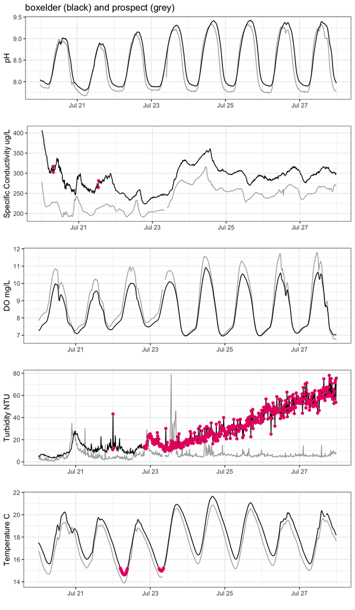

An example plot of flagged data at a site of interest, as well as the site upstream of it for comparison. Pink points indicate flagged data at the site of interest, while blue points indicate “suspect” data (if/when they exist in the time frame selected).

```r
site_name <- "boxelder"
start_date <- "2024-07-20"
end_date <- "2024-07-27"
# upstream site
up_name <- "prospect"

example_data <- final_flags %>%
  dplyr::mutate(date = lubridate::as_date(DT_round)) %>%
  dplyr::filter(site == site_name)%>%
  dplyr::filter(date >= start_date & date <= end_date)

up_dat <- final_flags %>%
  dplyr::mutate(date = lubridate::as_date(DT_round)) %>%
  dplyr::filter(site == up_name) %>%
  dplyr::filter(date >= start_date & date <= end_date)

pH <- ggplot() +
  geom_line(data = filter(up_dat, parameter == "pH"),
            aes(DT_round, mean), color = "darkgrey") +
  geom_line(data = filter(example_data, parameter == "pH"),
            aes(DT_round, mean)) +
  geom_point(data = filter(example_data, parameter == "pH" & !is.na(flag)),
             aes(DT_round, mean), color = "#E70870") +
    geom_point(data = filter(example_data, parameter == "pH" & flag == "suspect data"),
             aes(DT_round, mean), color = "#256BF5" ) +
  ylab("pH") + xlab("") +
  ggtitle(paste0(site_name, " (black) and ", up_name, " (grey)")) +
  theme_bw()

specific_conductivity <-   ggplot() +
    geom_line(data = filter(up_dat, parameter == "Specific Conductivity"),
            aes(DT_round, mean), color = "darkgrey") +
  geom_line(data = filter(example_data, parameter == "Specific Conductivity"),
            aes(DT_round, mean)) +
  geom_point(data = filter(example_data, parameter == "Specific Conductivity" & !is.na(flag)),
             aes(DT_round, mean), color = "#E70870") +
    geom_point(data = filter(example_data, parameter == "Specific Conductivity" & flag == "suspect data"),
             aes(DT_round, mean), color = "#256BF5" ) +
  ylab("Specific Conductivity ug/L") + xlab("") +
  theme_bw()

dissolved_oxygen <-  ggplot() +
    geom_line(data = filter(up_dat, parameter == "DO"),
            aes(DT_round, mean), color = "darkgrey") +
  geom_line(data = filter(example_data, parameter == "DO"),
            aes(DT_round, mean)) +
  geom_point(data = filter(example_data, parameter == "DO" & !is.na(flag)),
             aes(DT_round, mean), color = "#E70870") +
    geom_point(data = filter(example_data, parameter == "DO" & flag == "suspect data"),
             aes(DT_round, mean), color = "#256BF5" ) +
  ylab("DO mg/L") + xlab("") +
  theme_bw()

turbidity <- ggplot() +
    geom_line(data = filter(up_dat, parameter == "Turbidity"),
            aes(DT_round, mean), color = "darkgrey") +
  geom_line(data = filter(example_data, parameter == "Turbidity"),
            aes(DT_round, mean)) +
  geom_point(data = filter(example_data, parameter == "Turbidity" & !is.na(flag)),
             aes(DT_round, mean), color = "#E70870") +
    geom_point(data = filter(example_data, parameter == "Turbidity" & flag == "suspect data"),
             aes(DT_round, mean), color = "#256BF5" ) +
  ylab("Turbidity NTU") + xlab("") +
  theme_bw()

temp <- ggplot() +
    geom_line(data = filter(up_dat, parameter == "Temperature"),
            aes(DT_round, mean), color = "darkgrey") +
  geom_line(data = filter(example_data, parameter == "Temperature"),
            aes(DT_round, mean)) +
  geom_point(data = filter(example_data, parameter == "Temperature" & !is.na(flag)),
             aes(DT_round, mean), color = "#E70870") +
    geom_point(data = filter(example_data, parameter == "Temperature" & flag == "suspect data"),
             aes(DT_round, mean), color = "#256BF5" ) +
  ylab("Temperature C") + xlab("") +
  theme_bw()

ggarrange(pH, specific_conductivity, dissolved_oxygen, turbidity, temp,
          ncol = 1)
```